# FMST

Github Link:https://github.com/angels21/fmst

### Concrete Strength Prediction

Compressive strength or compression strength is the capacity of a material or structure to withstand loads tending to reduce size, as opposed to tensile strength, which withstands loads tending to elongate.

compressive strength is one of the most important engineering properties of concrete. It is a standard industrial practice that the concrete is classified based on grades. This grade is nothing but the Compressive Strength of the concrete cube or cylinder. Cube or Cylinder samples are usually tested under a compression testing machine to obtain the compressive strength of concrete. The test requisites differ country to country based on the design code.

The concrete compressive strength is a highly nonlinear function of age and ingredients .These ingredients include cement, blast furnace slag, fly ash, water, superplasticizer, coarse aggregate, and fine aggregate.

**Data Dictionary**:

**Name --Data Type --Measurement --Description**:

1.Cement (cement) --quantitative --kg in a m3 mixture --Input Variable  
2.Blast Furnace Slag (slag) --quantitative --kg ina m3 mixture --Input Variable  
3.Fly Ash (ash) --quantitative --kg ina m3 mixture --Input Variable  
4.Water(water) --quantitative --kg in a m3 mixture --Input Variable  
5.Superplasticizer (superplastic) --quantitative --kg in a m3 mixture --Input Variable  
6.Coarse Aggregate (coarseagg) --quantitative --kg in a m3 mixture --Input Variable  
7.Fine Aggregate (fineagg) --quantitative --kg in a m3 mixture --Input Variable  
8.Age(age) --quantitative --Day (1~365) --Input Variable  
9.Concrete compressive strength(strength) --quantitative --MPa --Output Variable

### Objective: To predict the concrete strength using the data available in file concrete_data.xls. Apply feature engineering and model tuning to obtain 80% to 95% of R2score.

### Steps and Tasks

#### Import Libraries

```python
import warnings
warnings.filterwarnings('ignore')
```

```python
import numpy as np

import pandas as pd # data processing, CSV file I/O (e.g. pd.read_csv)
from sklearn import metrics

from sklearn.linear_model import LogisticRegression
import matplotlib.pyplot as plt       # matplotlib.pyplot plots data
%matplotlib inline
import seaborn as sns
#To split data into training and testing
from sklearn.model_selection import train_test_split

# Import Linear Regression machine learning library
from sklearn.linear_model import LinearRegression
from sklearn.linear_model import Ridge
from sklearn.linear_model import Lasso

from sklearn.metrics import mean_squared_error, mean_absolute_error, r2_score

import os, sys
from scipy import stats
#Calculate accuracy measures and confusion matrix
from sklearn import metrics
import yellowbrick
from sklearn.tree import DecisionTreeClassifier
from sklearn.metrics import accuracy_score, f1_score, recall_score, precision_score, confusion_matrix

from yellowbrick.classifier import ClassificationReport, ROCAUC

plt.style.use('ggplot')
pd.options.display.float_format = '{:,.2f}'.format
from IPython.core.display import display, HTML
display(HTML("<style>.container { width:95% !important; }</style>"))
```

#### Load and review data

```python
data = pd.read_csv("concrete.csv")
```

```python
#Check data types
data.dtypes
```

```
cement          float64
slag            float64
ash             float64
water           float64
superplastic    float64
coarseagg       float64
fineagg         float64
age               int64
strength        float64
dtype: object
```

```
All feature data types are of the float type except age which is of the int type as expected
```

```python
#Statistical summary:range of values observed, central values (mean and median), standard deviation and quartiles
data.describe().transpose()
```

|  | count | mean | std | min | 25% | 50% | 75% | max |
| --- | --- | --- | --- | --- | --- | --- | --- | --- |
| cement | 1,030.00 | 281.17 | 104.51 | 102.00 | 192.38 | 272.90 | 350.00 | 540.00 |
| slag | 1,030.00 | 73.90 | 86.28 | 0.00 | 0.00 | 22.00 | 142.95 | 359.40 |
| ash | 1,030.00 | 54.19 | 64.00 | 0.00 | 0.00 | 0.00 | 118.30 | 200.10 |
| water | 1,030.00 | 181.57 | 21.35 | 121.80 | 164.90 | 185.00 | 192.00 | 247.00 |
| superplastic | 1,030.00 | 6.20 | 5.97 | 0.00 | 0.00 | 6.40 | 10.20 | 32.20 |
| coarseagg | 1,030.00 | 972.92 | 77.75 | 801.00 | 932.00 | 968.00 | 1,029.40 | 1,145.00 |
| fineagg | 1,030.00 | 773.58 | 80.18 | 594.00 | 730.95 | 779.50 | 824.00 | 992.60 |
| age | 1,030.00 | 45.66 | 63.17 | 1.00 | 7.00 | 28.00 | 56.00 | 365.00 |
| strength | 1,030.00 | 35.82 | 16.71 | 2.33 | 23.71 | 34.45 | 46.14 | 82.60 |

```
From the statistical summary, it can be seen that coarse aggregate while super plasticizer, slag, and ash have minimum entries of 0. Standard Deviation is minimum for superplaticizer and maximum for cement.
cement: the range of this attribute is 102 (min) to 540 (max). The mean (281.16) and median (272.90) values differ slightly. The standard deviation value is a bit high (104.50). For 75% of the given observations, this value is less than 350 (3rd quartile).
slag: the range of this attribute is 0 (min) to 359.40 (max). The mean (73.89) and median (22) values differ significantly indicating skewness of the distribution. The standard deviation value is 86.27. For 25% of the given observations, this value is 0..! (1st quartile).
ash: the range of this attribute is 0 (min) to 200 (max). Difference between the mean (54.18) and median (0) values is very high. The standard deviation value (64) is also high. For 50% of the given observations, this value is 0..! (2nd quartile). This attribute seems to have highly skewed distribution.
water: the range of this attribute is 121.8 (min) to 247 (max). The mean (181.56) and median (185) values differ slightly. The standard deviation value is 21.35. For 75% of the given observations, this value is 192 (3rd quartile). This attribute seems to have normal distribution.
superplastic: the range of this attribute is 0 (min) to 32.20 (max). Difference between the mean (620) and median (6.40) values is negligible. The standard deviation value is almost 6. For 25% of the given observations, this value is 0..! (1st quartile).
coarseagg: the range of this attribute is 801 (min) to 1145 (max). The mean (aprox. 973) and median (968) values differ slightly. The standard deviation value is 77.75. For 75% of the given observations, this value is 1029 (3rd quartile).
fineagg: the range of this attribute is 594 (min) to 992 (max). The mean (aprox. 773) and median (779) values differ slightly. The standard deviation value is 80.17. For 25% of the given observations, this value is 731 (1st quartile).
age: the range of this attribute is 1 (min) to 365 (max) days. The mean (approx. 46) and median (28) values differ significantly. The standard deviation value is approx 63 which is quite high. For 75% of the given observations, this value is 56 days (3rd quartile). This attribute seems to have skewed distribution.
```

```python
#Number of unique entries in each column
data.nunique()
```

```
cement          278
slag            185
ash             156
water           195
superplastic    111
coarseagg       284
fineagg         302
age              14
strength        845
dtype: int64
```

```python
# Getting unique values for each column, and display entries if unique value is less than 20
for a in list(data.columns):

    # get a list of unique values
    n = data[a].unique()

    # if number of unique values is less than 30, print the values. Otherwise print the number of unique values
    if len(n)<20:
        print(a)
        print(n)
    else:
        print(a + ': ' +str(len(n)) + ' unique values')
```

```
cement: 278 unique values
slag: 185 unique values
ash: 156 unique values
water: 195 unique values
superplastic: 111 unique values
coarseagg: 284 unique values
fineagg: 302 unique values
age
[ 28  14  90   7  56   3 100  91 180 365 270 360 120   1]
strength: 845 unique values
```

```
Age has the minimum number of unique entries while strength has the maximum number of unique entries
```

```python
#For correlation of all the variables

data.corr() # It will show correlation matrix
```

|  | cement | slag | ash | water | superplastic | coarseagg | fineagg | age | strength |
| --- | --- | --- | --- | --- | --- | --- | --- | --- | --- |
| cement | 1.00 | -0.28 | -0.40 | -0.08 | 0.09 | -0.11 | -0.22 | 0.08 | 0.50 |
| slag | -0.28 | 1.00 | -0.32 | 0.11 | 0.04 | -0.28 | -0.28 | -0.04 | 0.13 |
| ash | -0.40 | -0.32 | 1.00 | -0.26 | 0.38 | -0.01 | 0.08 | -0.15 | -0.11 |
| water | -0.08 | 0.11 | -0.26 | 1.00 | -0.66 | -0.18 | -0.45 | 0.28 | -0.29 |
| superplastic | 0.09 | 0.04 | 0.38 | -0.66 | 1.00 | -0.27 | 0.22 | -0.19 | 0.37 |
| coarseagg | -0.11 | -0.28 | -0.01 | -0.18 | -0.27 | 1.00 | -0.18 | -0.00 | -0.16 |
| fineagg | -0.22 | -0.28 | 0.08 | -0.45 | 0.22 | -0.18 | 1.00 | -0.16 | -0.17 |
| age | 0.08 | -0.04 | -0.15 | 0.28 | -0.19 | -0.00 | -0.16 | 1.00 | 0.33 |
| strength | 0.50 | 0.13 | -0.11 | -0.29 | 0.37 | -0.16 | -0.17 | 0.33 | 1.00 |

```
Cement has the strongest correlation to the target variable while ash has the weakest correlation to the target variable. Superplasticizer and water have the strongest correlation between features, while age and coarse aggregate have the weakest correlation between the variables.
```

```python
data.shape # Check number of columns and rows in data frame
```

```
(1030, 9)
```

```
There are 1030 rows and 9 colums in the data set
```

```python
data.head(10) # To check first 10 rows of data set
```

|  | cement | slag | ash | water | superplastic | coarseagg | fineagg | age | strength |
| --- | --- | --- | --- | --- | --- | --- | --- | --- | --- |
| 0 | 141.30 | 212.00 | 0.00 | 203.50 | 0.00 | 971.80 | 748.50 | 28 | 29.89 |
| 1 | 168.90 | 42.20 | 124.30 | 158.30 | 10.80 | 1,080.80 | 796.20 | 14 | 23.51 |
| 2 | 250.00 | 0.00 | 95.70 | 187.40 | 5.50 | 956.90 | 861.20 | 28 | 29.22 |
| 3 | 266.00 | 114.00 | 0.00 | 228.00 | 0.00 | 932.00 | 670.00 | 28 | 45.85 |
| 4 | 154.80 | 183.40 | 0.00 | 193.30 | 9.10 | 1,047.40 | 696.70 | 28 | 18.29 |
| 5 | 255.00 | 0.00 | 0.00 | 192.00 | 0.00 | 889.80 | 945.00 | 90 | 21.86 |
| 6 | 166.80 | 250.20 | 0.00 | 203.50 | 0.00 | 975.60 | 692.60 | 7 | 15.75 |
| 7 | 251.40 | 0.00 | 118.30 | 188.50 | 6.40 | 1,028.40 | 757.70 | 56 | 36.64 |
| 8 | 296.00 | 0.00 | 0.00 | 192.00 | 0.00 | 1,085.00 | 765.00 | 28 | 21.65 |
| 9 | 155.00 | 184.00 | 143.00 | 194.00 | 9.00 | 880.00 | 699.00 | 28 | 28.99 |

```
There are entries of zero in the table. This will be explored later to determine if they are unintended entries.
```

```python
data.tail(10) # To check last 10 rows of data set
```

|  | cement | slag | ash | water | superplastic | coarseagg | fineagg | age | strength |
| --- | --- | --- | --- | --- | --- | --- | --- | --- | --- |
| 1020 | 183.90 | 122.60 | 0.00 | 203.50 | 0.00 | 959.20 | 800.00 | 7 | 10.79 |
| 1021 | 203.50 | 305.30 | 0.00 | 203.50 | 0.00 | 963.40 | 630.00 | 3 | 9.56 |
| 1022 | 144.80 | 0.00 | 133.60 | 180.80 | 11.10 | 979.50 | 811.50 | 28 | 13.20 |
| 1023 | 141.30 | 212.00 | 0.00 | 203.50 | 0.00 | 971.80 | 748.50 | 7 | 10.39 |
| 1024 | 297.20 | 0.00 | 117.50 | 174.80 | 9.50 | 1,022.80 | 753.50 | 3 | 21.91 |
| 1025 | 135.00 | 0.00 | 166.00 | 180.00 | 10.00 | 961.00 | 805.00 | 28 | 13.29 |
| 1026 | 531.30 | 0.00 | 0.00 | 141.80 | 28.20 | 852.10 | 893.70 | 3 | 41.30 |
| 1027 | 276.40 | 116.00 | 90.30 | 179.60 | 8.90 | 870.10 | 768.30 | 28 | 44.28 |
| 1028 | 342.00 | 38.00 | 0.00 | 228.00 | 0.00 | 932.00 | 670.00 | 270 | 55.06 |
| 1029 | 540.00 | 0.00 | 0.00 | 173.00 | 0.00 | 1,125.00 | 613.00 | 7 | 52.61 |

Analysis of the body of distributions

```python
#checking distribution of cement quantity in a mixture
data['age'].value_counts(normalize=True).sort_index()
```

```
1     0.00
3     0.13
7     0.12
14    0.06
28    0.41
56    0.09
90    0.05
91    0.02
100   0.05
120   0.00
180   0.03
270   0.01
360   0.01
365   0.01
Name: age, dtype: float64
```

```
This variable is skewed towards the 28 days with 41 percent of the entries.
```

```
Distribution for Predictive and Target(strength) variables
```

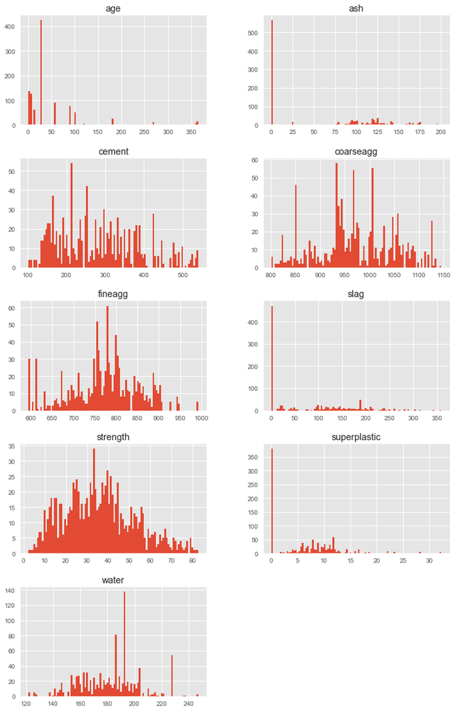

```python
#Univariate plots of predictor and target variables
columns = list(data)
data[columns].hist(stacked=False, bins=100, figsize=(12,40), layout=(10,2));
# Histogram of first 8 columns
```

[output not shown]

```python
#Checking the exact amount of skewness
data.skew().sort_values(ascending=False)
```

```
age             3.27
superplastic    0.91
slag            0.80
ash             0.54
cement          0.51
strength        0.42
water           0.07
coarseagg      -0.04
fineagg        -0.25
dtype: float64
```

```
Distribition of most of the columns are right skewed
Water and coarseag have approximately symmetric distributions
Attributes coarseagg and fineagg show negative skewness
```

Checking missing values

```python
data.isnull().sum() # Checking if there are any null values in data set
```

```
cement          0
slag            0
ash             0
water           0
superplastic    0
coarseagg       0
fineagg         0
age             0
strength        0
dtype: int64
```

```
No missing data
```

```python
#Checking for NaN entries in the dataset
data.isna().values.any()
```

```
False
```

```
No non number entries
```

```
As mentioned earlier, we will check if the zero entries are unintended. When mixing concrete, certain ingredients cannot have zero amount while some can. For our data set, cement and  water are key ingredients and must have non-zero quantities. Also, while the compressive strength of the concrete cannot be zero, even when the mixture is freshly poured, the test is normally carried out a few days after the mixture is being poured. This implies that age and strength must have non-zero values. This would be investigated below.
```

```python
data[data.cement == 0].values.any()
```

```
False
```

```python
data[data.water == 0].values.any()
```

```
False
```

```python
data[data.age == 0].values.any()
```

```
False
```

```python
data[data.strength == 0].values.any()
```

```
False
```

```
Since all four parameters of interest above have non-zero entries, we can conclude that it is unlikely the zero entries for the other remaining parameters (slage,ash,superplasticizer, coarse and fine aggregate) are unintended because they can have zero entries.
```

```python
data.isnull().sum()
```

```
cement          0
slag            0
ash             0
water           0
superplastic    0
coarseagg       0
fineagg         0
age             0
strength        0
dtype: int64
```

```
No non-null entries
```

Checking for Outliers

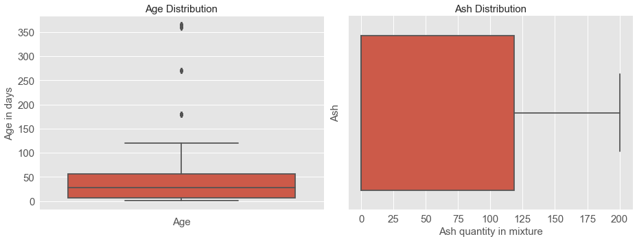

```python
#Checking outliers for age and ash quantity
fig, (ax1, ax2) = plt.subplots(nrows = 1, ncols = 2, figsize = (13, 5))
sns.boxplot(x = 'age', data = data, orient = 'v', ax = ax1)
ax1.set_xlabel('Age', fontsize=15)
ax1.set_ylabel('Age in days', fontsize=15)
ax1.set_title('Age Distribution', fontsize=15)
ax1.tick_params(labelsize=15)

sns.boxplot(data['ash'], ax = ax2)
sns.despine(ax = ax2)
ax2.set_xlabel('Ash quantity in mixture', fontsize=15)
ax2.set_ylabel('Ash', fontsize=15)
ax2.set_title('Ash Distribution', fontsize=15)
ax2.tick_params(labelsize=15)

plt.subplots_adjust(wspace=0.5)
plt.tight_layout()
```

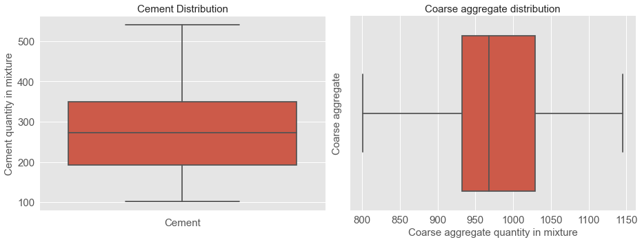

```python
#Checking outliers for day and duration
fig, (ax1, ax2) = plt.subplots(nrows = 1, ncols = 2, figsize = (13, 5))
sns.boxplot(x = 'cement', data = data, orient = 'v', ax = ax1)
ax1.set_xlabel('Cement', fontsize=15)
ax1.set_ylabel('Cement quantity in mixture', fontsize=15)
ax1.set_title('Cement Distribution', fontsize=15)
ax1.tick_params(labelsize=15)

sns.boxplot(data['coarseagg'], ax = ax2)
sns.despine(ax = ax2)
ax2.set_xlabel('Coarse aggregate quantity in mixture', fontsize=15)
ax2.set_ylabel('Coarse aggregate', fontsize=15)
ax2.set_title('Coarse aggregate distribution', fontsize=15)
ax2.tick_params(labelsize=15)

plt.subplots_adjust(wspace=0.5)
plt.tight_layout()
```

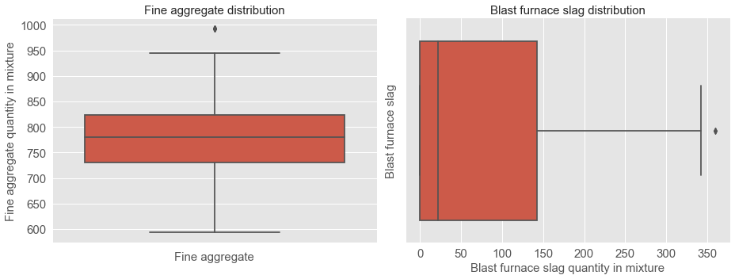

```python
#Checking outliers for campaign and pdays
fig, (ax1, ax2) = plt.subplots(nrows = 1, ncols = 2, figsize = (13, 5))
sns.boxplot(x = 'fineagg', data = data, orient = 'v', ax = ax1)
ax1.set_xlabel('Fine aggregate', fontsize=15)
ax1.set_ylabel('Fine aggregate quantity in mixture', fontsize=15)
ax1.set_title('Fine aggregate distribution', fontsize=15)
ax1.tick_params(labelsize=15)

sns.boxplot(data['slag'], ax = ax2)
sns.despine(ax = ax2)
ax2.set_xlabel('Blast furnace slag quantity in mixture', fontsize=15)
ax2.set_ylabel('Blast furnace slag', fontsize=15)
ax2.set_title('Blast furnace slag distribution', fontsize=15)
ax2.tick_params(labelsize=15)

plt.subplots_adjust(wspace=0.5)
plt.tight_layout()
```

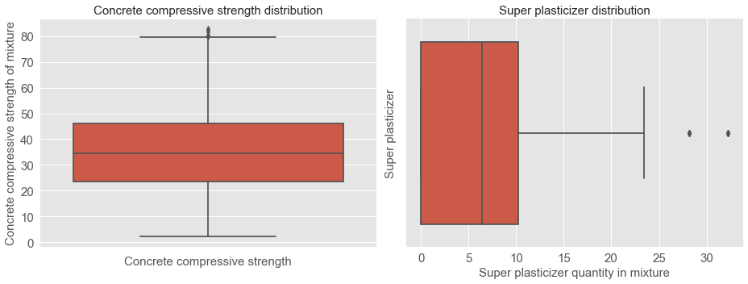

```python
#Checking outliers for concrete compressive strength and super plasticizer
fig, (ax1, ax2) = plt.subplots(nrows = 1, ncols = 2, figsize = (13, 5))
sns.boxplot(x = 'strength', data = data, orient = 'v', ax = ax1)
ax1.set_xlabel('Concrete compressive strength', fontsize=15)
ax1.set_ylabel('Concrete compressive strength of mixture', fontsize=15)
ax1.set_title('Concrete compressive strength distribution', fontsize=15)
ax1.tick_params(labelsize=15)

sns.boxplot(data['superplastic'], ax = ax2)
sns.despine(ax = ax2)
ax2.set_xlabel('Super plasticizer quantity in mixture', fontsize=15)
ax2.set_ylabel('Super plasticizer', fontsize=15)
ax2.set_title('Super plasticizer distribution', fontsize=15)
ax2.tick_params(labelsize=15)

plt.subplots_adjust(wspace=0.5)
plt.tight_layout()
```

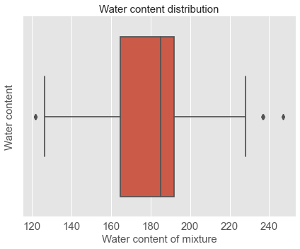

```python
#Checking outliers for water content
fig, (ax2) = plt.subplots(nrows = 1, ncols = 1, figsize = (6, 5))
sns.boxplot(data['water'], ax = ax2)
sns.despine(ax = ax2)
ax2.set_xlabel('Water content of mixture', fontsize=15)
ax2.set_ylabel('Water content', fontsize=15)
ax2.set_title('Water content distribution', fontsize=15)
ax2.tick_params(labelsize=15)

plt.tight_layout()
```

```python
#number and percentage of outliers in each column
q1=data.quantile(0.25)
q3=data.quantile(0.75)
IQR=q3-q1
cwo=((data.iloc[:] <(q1-1.5*IQR))|(data.iloc[:]>(q3+1.5*IQR))).sum(axis=0)
opdf=pd.DataFrame(cwo,index=data.columns,columns=['No. of Outliers'])
opdf['Percentage Outliers']=round(opdf['No. of Outliers']*100/len(data),2)
opdf
```

|  | No. of Outliers | Percentage Outliers |
| --- | --- | --- |
| cement | 0 | 0.00 |
| slag | 2 | 0.19 |
| ash | 0 | 0.00 |
| water | 9 | 0.87 |
| superplastic | 10 | 0.97 |
| coarseagg | 0 | 0.00 |
| fineagg | 5 | 0.49 |
| age | 59 | 5.73 |
| strength | 4 | 0.39 |

```
The boxplots above shows that all the predictor variables have outliers except ash, cement and coarse aggregate quantity. The outliers would be treated later using an imputer
```

Checking for duplicate rows

```python
#To check for duplicated rows
Data = data.copy()
Data['cement'] = Data.groupby(['cement', 'slag']).cement.transform('idxmin')
Data[Data.duplicated(subset=None, keep="first")]
```

|  | cement | slag | ash | water | superplastic | coarseagg | fineagg | age | strength |
| --- | --- | --- | --- | --- | --- | --- | --- | --- | --- |
| 278 | 27 | 106.30 | 0.00 | 153.50 | 16.50 | 852.10 | 887.10 | 3 | 33.40 |
| 298 | 27 | 106.30 | 0.00 | 153.50 | 16.50 | 852.10 | 887.10 | 3 | 33.40 |
| 400 | 88 | 189.00 | 0.00 | 164.90 | 11.60 | 944.70 | 755.80 | 3 | 35.30 |
| 420 | 88 | 189.00 | 0.00 | 164.90 | 11.60 | 944.70 | 755.80 | 3 | 35.30 |
| 463 | 88 | 189.00 | 0.00 | 164.90 | 11.60 | 944.70 | 755.80 | 56 | 77.30 |
| 468 | 154 | 0.00 | 0.00 | 185.00 | 0.00 | 1,111.00 | 784.00 | 28 | 19.69 |
| 482 | 27 | 106.30 | 0.00 | 153.50 | 16.50 | 852.10 | 887.10 | 91 | 65.20 |
| 493 | 88 | 189.00 | 0.00 | 164.90 | 11.60 | 944.70 | 755.80 | 91 | 79.30 |
| 517 | 27 | 106.30 | 0.00 | 153.50 | 16.50 | 852.10 | 887.10 | 56 | 64.30 |
| 525 | 88 | 189.00 | 0.00 | 164.90 | 11.60 | 944.70 | 755.80 | 28 | 71.30 |
| 527 | 27 | 106.30 | 0.00 | 153.50 | 16.50 | 852.10 | 887.10 | 91 | 65.20 |
| 576 | 88 | 189.00 | 0.00 | 164.90 | 11.60 | 944.70 | 755.80 | 7 | 55.90 |
| 577 | 27 | 106.30 | 0.00 | 153.50 | 16.50 | 852.10 | 887.10 | 28 | 60.29 |
| 604 | 88 | 189.00 | 0.00 | 164.90 | 11.60 | 944.70 | 755.80 | 56 | 77.30 |
| 733 | 88 | 189.00 | 0.00 | 164.90 | 11.60 | 944.70 | 755.80 | 91 | 79.30 |
| 738 | 88 | 189.00 | 0.00 | 164.90 | 11.60 | 944.70 | 755.80 | 28 | 71.30 |
| 766 | 88 | 189.00 | 0.00 | 164.90 | 11.60 | 944.70 | 755.80 | 91 | 79.30 |
| 830 | 27 | 106.30 | 0.00 | 153.50 | 16.50 | 852.10 | 887.10 | 7 | 49.20 |
| 880 | 27 | 106.30 | 0.00 | 153.50 | 16.50 | 852.10 | 887.10 | 56 | 64.30 |
| 884 | 27 | 106.30 | 0.00 | 153.50 | 16.50 | 852.10 | 887.10 | 7 | 49.20 |
| 892 | 88 | 189.00 | 0.00 | 164.90 | 11.60 | 944.70 | 755.80 | 56 | 77.30 |
| 933 | 88 | 189.00 | 0.00 | 164.90 | 11.60 | 944.70 | 755.80 | 7 | 55.90 |
| 943 | 88 | 189.00 | 0.00 | 164.90 | 11.60 | 944.70 | 755.80 | 3 | 35.30 |
| 967 | 88 | 189.00 | 0.00 | 164.90 | 11.60 | 944.70 | 755.80 | 28 | 71.30 |
| 992 | 27 | 106.30 | 0.00 | 153.50 | 16.50 | 852.10 | 887.10 | 28 | 60.29 |

```
The following rows are duplicates 278 and 298, 400 and 420, 482 and 527, 493 and 766, 517 and 880, 525 and 967, 733 and 766, 830 and 884. Since they are few, they wont affect the result of the analysis.
```

```python
data.head()
```

|  | cement | slag | ash | water | superplastic | coarseagg | fineagg | age | strength |
| --- | --- | --- | --- | --- | --- | --- | --- | --- | --- |
| 0 | 141.30 | 212.00 | 0.00 | 203.50 | 0.00 | 971.80 | 748.50 | 28 | 29.89 |
| 1 | 168.90 | 42.20 | 124.30 | 158.30 | 10.80 | 1,080.80 | 796.20 | 14 | 23.51 |
| 2 | 250.00 | 0.00 | 95.70 | 187.40 | 5.50 | 956.90 | 861.20 | 28 | 29.22 |
| 3 | 266.00 | 114.00 | 0.00 | 228.00 | 0.00 | 932.00 | 670.00 | 28 | 45.85 |
| 4 | 154.80 | 183.40 | 0.00 | 193.30 | 9.10 | 1,047.40 | 696.70 | 28 | 18.29 |

**ii. Multivariate analysis(8marks)**:  
a. Bi-variate analysis between the predictor variables and target column. Comment on your findings in terms of their relationship and degree of relation if any. Visualize the analysis using boxplots and pair plots, histograms or density curves. Select the most appropriate attributes.  
b. Please provide comments in jupyter notebook regarding the steps you take and insights drawn from the plots

```python
# To see correlation in graphical, below is function for that
def plot_corr(data, size=11):
    corr = data.corr()
    fig, ax = plt.subplots(figsize=(size, size))
    ax.matshow(corr)
    plt.xticks(range(len(corr.columns)), corr.columns)
    plt.yticks(range(len(corr.columns)), corr.columns)
    for (i, j), z in np.ndenumerate(corr):
        ax.text(j, i, '{:0.1f}'.format(z), ha='center', va='center')
```

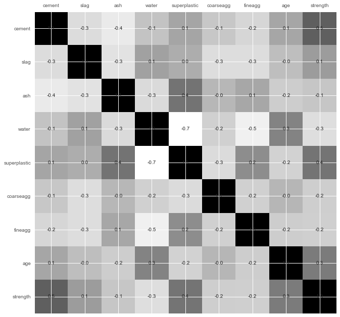

```python
plot_corr(data)
```

There is a weak correlation between all the variables except water and super plasticizer

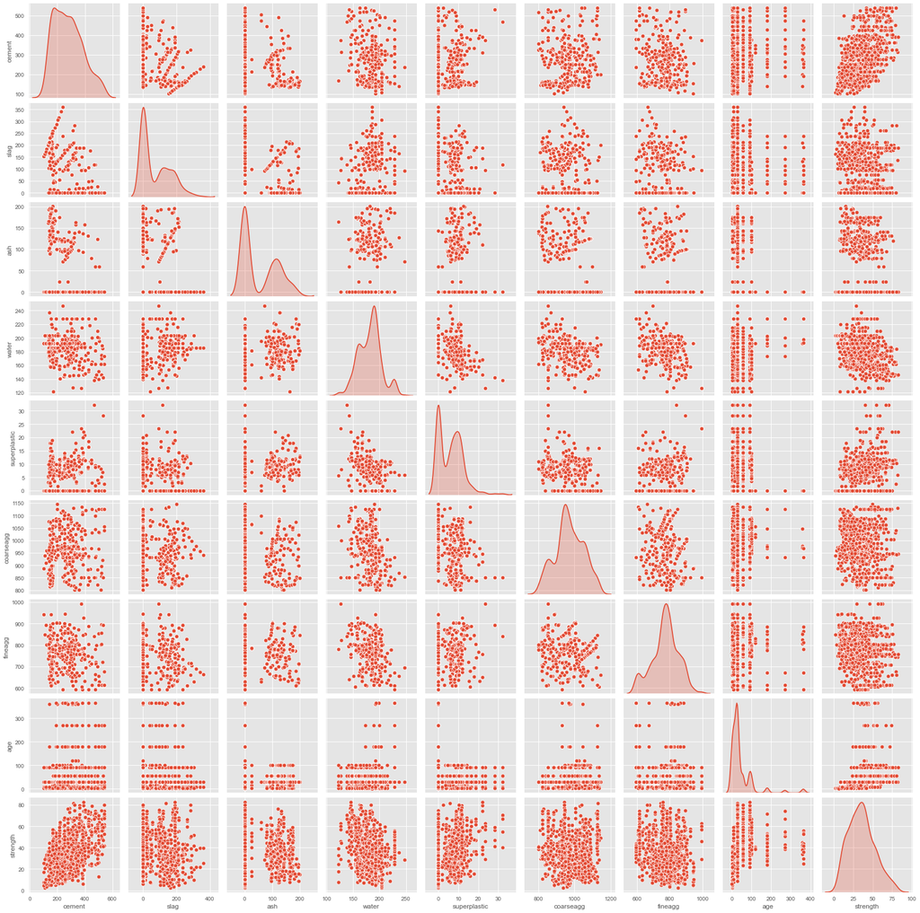

```python
#Bi-variate pairplots between the predictor variables using kernel density estimate
sns.pairplot(data,diag_kind='kde')
plt.show()
```

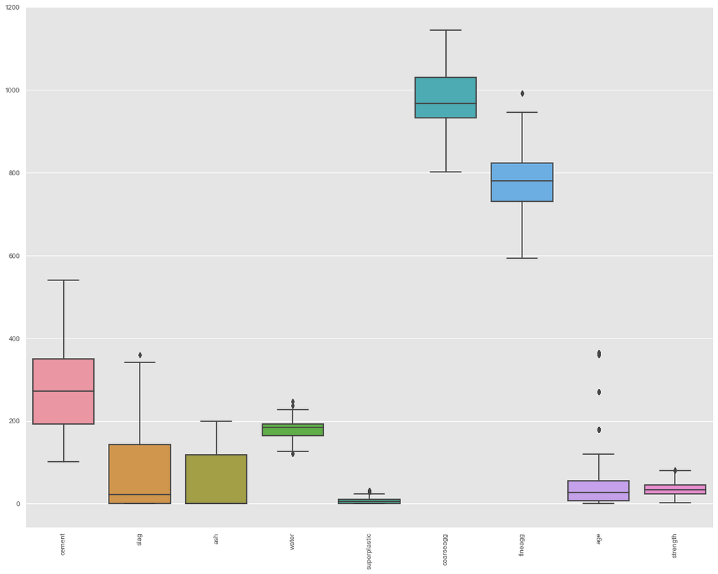

```python
#Box plots of all variables relative to each other
plt.figure(figsize=(18,14))
box = sns.boxplot(data=data)
box.set_xticklabels(labels=box.get_xticklabels(),rotation=90);
```

**Multivariate Analysis Insights**:

```
i.  water quantity seems to be negatively related with strength
ii. Duration of cure (age) do not show any relation with other independent attributes.
iii. fineagg and coarseagg shows slight negative linear relationship with water
iv. superplastic attribute has negative correlation with the water.
v. Except for strength and cement attributes, density curves for most of the attribute show multiple peaks
```

**3.Feature Engineering techniques(10 marks)**:  
a.Identify opportunities (if any) to extracta new featurefrom existing features, drop a feature(if required)  
b.Get data model ready and do a train test split.  
c.Decide on complexity of the model, should it be simple linear model in terms of parameters or would aquadratic or higher degree.

```
Water to Cement ratio is a good predictor of the strength of a concrete. Smaller values of water-cement ratio (W/C) are associated with higher values of concrete strength where as higher values of ratio provide small concrete strength. We will use this ratio as a new feature in order to improve the model performance
```

```python
#Adding water to cemnt ratio feature to the data
data['water-cement-ratio'] = data['water'] / data['cement']
```

```python
# Check top 5 rows and confirm feature has been added
data.head()
```

|  | cement | slag | ash | water | superplastic | coarseagg | fineagg | age | strength | water-cement-ratio |
| --- | --- | --- | --- | --- | --- | --- | --- | --- | --- | --- |
| 0 | 141.30 | 212.00 | 0.00 | 203.50 | 0.00 | 971.80 | 748.50 | 28 | 29.89 | 1.44 |
| 1 | 168.90 | 42.20 | 124.30 | 158.30 | 10.80 | 1,080.80 | 796.20 | 14 | 23.51 | 0.94 |
| 2 | 250.00 | 0.00 | 95.70 | 187.40 | 5.50 | 956.90 | 861.20 | 28 | 29.22 | 0.75 |
| 3 | 266.00 | 114.00 | 0.00 | 228.00 | 0.00 | 932.00 | 670.00 | 28 | 45.85 | 0.86 |
| 4 | 154.80 | 183.40 | 0.00 | 193.30 | 9.10 | 1,047.40 | 696.70 | 28 | 18.29 | 1.25 |

```python
data.corr()
```

|  | cement | slag | ash | water | superplastic | coarseagg | fineagg | age | strength | water-cement-ratio |
| --- | --- | --- | --- | --- | --- | --- | --- | --- | --- | --- |
| cement | 1.00 | -0.28 | -0.40 | -0.08 | 0.09 | -0.11 | -0.22 | 0.08 | 0.50 | -0.88 |
| slag | -0.28 | 1.00 | -0.32 | 0.11 | 0.04 | -0.28 | -0.28 | -0.04 | 0.13 | 0.36 |
| ash | -0.40 | -0.32 | 1.00 | -0.26 | 0.38 | -0.01 | 0.08 | -0.15 | -0.11 | 0.25 |
| water | -0.08 | 0.11 | -0.26 | 1.00 | -0.66 | -0.18 | -0.45 | 0.28 | -0.29 | 0.33 |
| superplastic | 0.09 | 0.04 | 0.38 | -0.66 | 1.00 | -0.27 | 0.22 | -0.19 | 0.37 | -0.22 |
| coarseagg | -0.11 | -0.28 | -0.01 | -0.18 | -0.27 | 1.00 | -0.18 | -0.00 | -0.16 | -0.03 |
| fineagg | -0.22 | -0.28 | 0.08 | -0.45 | 0.22 | -0.18 | 1.00 | -0.16 | -0.17 | 0.07 |
| age | 0.08 | -0.04 | -0.15 | 0.28 | -0.19 | -0.00 | -0.16 | 1.00 | 0.33 | -0.03 |
| strength | 0.50 | 0.13 | -0.11 | -0.29 | 0.37 | -0.16 | -0.17 | 0.33 | 1.00 | -0.50 |
| water-cement-ratio | -0.88 | 0.36 | 0.25 | 0.33 | -0.22 | -0.03 | 0.07 | -0.03 | -0.50 | 1.00 |

```
The water cement ratio is strongly negatively correlated to the cement and also slightly correlated to the strength.
```

```python
data.columns
```

```
Index(['cement', 'slag', 'ash', 'water', 'superplastic', 'coarseagg',
       'fineagg', 'age', 'strength', 'water-cement-ratio'],
      dtype='object')
```

```python
#Outliers will be treated using MICE (Multiple Imputation using Chained Equations) approach after these outliers are considered as missing values
#This imputer will estimate each feature from all the others.
from sklearn.experimental import enable_iterative_imputer
from sklearn.impute import IterativeImputer

imp = IterativeImputer()
imp.fit(data)
data=pd.DataFrame(imp.transform(data),columns=data.columns)
```

```python
## Define X and y variables
X = data.drop(columns= ['water','strength'])#'strength', axis=1
y = data[['strength']]
```

```python
from sklearn.model_selection import train_test_split

X_train, X_test, y_train, y_test = train_test_split(X, y, test_size=0.20, random_state=1)
```

```python
from sklearn.preprocessing import StandardScaler
scaler = StandardScaler()

X_train = scaler.fit_transform(X_train)
X_train = pd.DataFrame(X_train, columns=X.columns)
X_test = scaler.transform(X_test)
X_test = pd.DataFrame(X_test, columns=X.columns)
```

```python
#fit a simple linear model
regression_model = LinearRegression()
regression_model.fit(X_train, y_train)
y_pred = regression_model.predict(X_test)

scoreTr1 = regression_model.score(X_train, y_train)
scoreTe1 = regression_model.score(X_test, y_test)
MSE1 = mean_squared_error(y_test, y_pred)
MAE1 = mean_absolute_error(y_test, y_pred)
#print train and test score and other metrics of the model
print('Training Score: ',scoreTr1)
print('Testing Score: ',scoreTe1)
print('Mean Squared Error: ',MSE1)
print('Mean Absolute Error: ',MAE1)
```

```
Training Score:  0.6089749904139687
Testing Score:  0.6306690544915381
Mean Squared Error:  108.75659502606875
Mean Absolute Error:  8.29705109394644
```

```
The low correlation of the predictor variables towards the target variable implies that a linear model is not suitable for this problem, Hence we would use higher degree models
```

```python
# fitting a quadratic model
from sklearn.preprocessing import PolynomialFeatures
from sklearn import linear_model

poly = PolynomialFeatures(degree=2, interaction_only=True)
X_train2 = poly.fit_transform(X_train)
X_test2 = poly.fit_transform(X_test)

poly_clf = linear_model.LinearRegression()

poly_clf.fit(X_train2, y_train)

y_predpo = poly_clf.predict(X_test2)

scoreTr2 = poly_clf.score(X_train2, y_train)
scoreTe2 = poly_clf.score(X_test2, y_test)
MSE2 = mean_squared_error(y_test, y_predpo)
MAE2 = mean_absolute_error(y_test, y_predpo)

#In sample (training) R^2 will always improve with the number of variables!
print('Training Score: ',scoreTr2)
print('Testing Score: ',scoreTe2)
print('Mean Squared Error: ',MSE2)
print('Mean Absolute Error: ',MAE2)
```

```
Training Score:  0.7481051111955022
Testing Score:  0.7551692683227889
Mean Squared Error:  72.09511431081664
Mean Absolute Error:  6.961540658753812
```

```python
print(X_train.shape)
print(X_train2.shape)
```

```
(824, 8)
(824, 37)
```

[output not shown]

```python
#fitting a cubic model
from sklearn.preprocessing import PolynomialFeatures
from sklearn import linear_model

poly = PolynomialFeatures(degree=3, interaction_only=True)
X_train3 = poly.fit_transform(X_train)
X_test3 = poly.fit_transform(X_test)

poly_clf = linear_model.LinearRegression()

poly_clf.fit(X_train3, y_train)

y_predpo = poly_clf.predict(X_test3)

scoreTr22 = poly_clf.score(X_train3, y_train)
scoreTe22 = poly_clf.score(X_test3, y_test)
MSE22 = mean_squared_error(y_test, y_predpo)
MAE22 = mean_absolute_error(y_test, y_predpo)

#In sample (training) R^2 will always improve with the number of variables!
print('Training Score: ',scoreTr22)
print('Testing Score: ',scoreTe22)
print('Mean Squared Error: ',MSE22)
print('Mean Absolute Error: ',MAE22)
```

```
Training Score:  0.8046878524302989
Testing Score:  0.7738839237698265
Mean Squared Error:  66.58422434002418
Mean Absolute Error:  6.643278181538013
```

```python
print(X_train.shape)
print(X_train2.shape)
print(X_train3.shape)
```

```
(824, 8)
(824, 37)
(824, 93)
```

```
Out of sample testing score does improve but again the features increased significantly by 85 additional columns. From the training score, it can be seen that the model is now overfit. Hence to eek out additional perfomance, one can regularize using LASSO regularization. This will not only select the most useful feature, it will also reduce overfitting.
```

**Creating the model and tuning it**:  
1.Algorithms that you think will be suitable for this project.Use Kfold Cross Validation toevaluate model performance.Use appropriate metrics and make a DataFrame to compare models w.r.t their metrics.(at least 3 algorithms, one bagging and one boosting based algorithms has to be there).(15 marks)

#### Decision Tree Regressor

```
Another algorithm that would give better performance in this case would be Decision Trees, since we have a lot of zeros in some of the input features as seen from their distributions in the pair plot above. This would help the decision trees build trees based on some conditions on features which can further improve performance.
```

```python
from sklearn.tree import DecisionTreeRegressor

dtr = DecisionTreeRegressor()

dtr.fit(X_train, y_train)

y_pred_dttr=dtr.predict(X_train)
y_pred_dtte = dtr.predict(X_test)

scoreTr3 = r2_score(y_train,y_pred_dttr)
scoreTe3 = r2_score(y_test,y_pred_dtte)
MSE3 = mean_squared_error(y_test, y_pred_dtte)
MAE3 = mean_absolute_error(y_test, y_pred_dtte)


print('Training Score: ',scoreTr3)
print('Testing Score: ',scoreTe3)
print('Mean Squared Error: ',MSE3)
print('Mean Absolute Error: ',MAE3)
```

```
Training Score:  0.9954299462497965
Testing Score:  0.8716716143072353
Mean Squared Error:  37.788759492988135
Mean Absolute Error:  4.016229773462784
```

#### Random Forest Regressor

```
Since Using a Decision Tree Regressor has improved our performance, we can further improve the performance by ensembling more trees. Random Forest Regressor trains randomly initialized trees with random subsets of data sampled from the training data, this will make our model more robust
```

```python
from sklearn.ensemble import RandomForestRegressor

rfr = RandomForestRegressor(n_estimators=100)

rfr.fit(X_train, y_train)
y_pred_rftr=rfr.predict(X_train)
y_pred_rfte = rfr.predict(X_test)

scoreTr4 = r2_score(y_train,y_pred_rftr)
scoreTe4 = r2_score(y_test,y_pred_rfte)
MSE4 = mean_squared_error(y_test, y_pred_rfte)
MAE4 = mean_absolute_error(y_test, y_pred_rfte)


print('Training Score: ',scoreTr4)
print('Testing Score: ',scoreTe4)
print('Mean Squared Error: ',MSE4)
print('Mean Absolute Error: ',MAE4)
```

```
Training Score:  0.9844072862263293
Testing Score:  0.9122125562921295
Mean Squared Error:  25.85069997469774
Mean Absolute Error:  3.490382632759636
```

#### Adaboost regressor

```python
from sklearn.ensemble import AdaBoostRegressor
abr = AdaBoostRegressor(random_state=0, n_estimators=100)
abr.fit(X_train, y_train)
abr.feature_importances_
abr.fit(X_train,y_train)
abr.score(X_train,y_train)
y_pred_abrtr=abr.predict(X_train)
y_pred_abrte=abr.predict(X_test)

scoreTr5 = r2_score(y_train,y_pred_abrtr)
scoreTe5 = r2_score(y_test,y_pred_abrte)
MSE5 = mean_squared_error(y_test, y_pred_abrte)
MAE5 = mean_absolute_error(y_test, y_pred_abrte)


print('Training Score: ',scoreTr5)
print('Testing Score: ',scoreTe5)
print('Mean Squared Error: ',MSE5)
print('Mean Absolute Error: ',MAE5)
```

```
Training Score:  0.824163270058703
Testing Score:  0.7834629506070512
Mean Squared Error:  63.763495789792216
Mean Absolute Error:  6.770249290283237
```

#### Bagging regressor

```python
#Bagging without SVM
from sklearn.ensemble import BaggingRegressor
regr = BaggingRegressor(n_estimators=200, random_state=0).fit(X_train, y_train)
regr.score(X_train,y_train)
y_pred_regrtr=regr.predict(X_train)
y_pred_regrte=regr.predict(X_test)

scoreTr6 = r2_score(y_train,y_pred_regrtr)
scoreTe6 = r2_score(y_test,y_pred_regrte)
MSE6 = mean_squared_error(y_test, y_pred_regrte)
MAE6 = mean_absolute_error(y_test, y_pred_regrte)


print('Training Score: ',scoreTr6)
print('Testing Score: ',scoreTe6)
print('Mean Squared Error: ',MSE6)
print('Mean Absolute Error: ',MAE6)
```

```
Training Score:  0.9850036684331734
Testing Score:  0.9138992861781462
Mean Squared Error:  25.35400994272832
Mean Absolute Error:  3.449343204654039
```

Cross Validation Score

```python
from sklearn.model_selection import cross_val_score
#Cross Validation score for Decision Tree dt
score7 = cross_val_score(dtr, X, y, cv = 10).mean()
print(f'Cross validation score of Decision tree = {score7}')
```

```
Cross validation score of Decision tree = 0.85572234830738
```

```python
#Cross Validation score for Random Forest rf
score8 = cross_val_score(rfr, X, y, cv = 10).mean()
print(f'Cross validation score of Random forest = {score8}')
```

```
Cross validation score of Random forest = 0.9184583430544941
```

```python
#Cross Validation score for adaboost
score9 = cross_val_score(abr, X, y, cv = 10).mean()
print(f'Cross validation score of Boosting = {score9}')
```

```
Cross validation score of Boosting = 0.7780503334518263
```

```python
#Cross Validation score for Bagging
score10 = cross_val_score(regr, X, y, cv = 10).mean()
print(f'Cross validation score of Bagging  = {score10}')
```

```
Cross validation score of Bagging  = 0.9192906695513248
```

```python
#Dataframe to display result
dataresult1 = {'Technique' : ['Decision tree',
                       'Random forest', 'AdaBoost','Bagging'],
               'Training Score' : [scoreTr3, scoreTr4, scoreTr5, scoreTr6],
       'Testing Score' : [scoreTe3, scoreTe4, scoreTe5, scoreTe6],
               'CV_Score' : [score7, score8, score9, score10],
               'Mean Squared Error' : [ MSE3, MSE4, MSE5, MSE6],
               'Mean Absolute Error' : [ MAE3, MAE4, MAE5, MAE6]

              }

result1 = pd.DataFrame(dataresult1)
result1
```

|  | Technique | Training Score | Testing Score | CV_Score | Mean Squared Error | Mean Absolute Error |
| --- | --- | --- | --- | --- | --- | --- |
| 0 | Decision tree | 1.00 | 0.87 | 0.86 | 37.79 | 4.02 |
| 1 | Random forest | 0.98 | 0.91 | 0.92 | 25.85 | 3.49 |
| 2 | AdaBoost | 0.82 | 0.78 | 0.78 | 63.76 | 6.77 |
| 3 | Bagging | 0.99 | 0.91 | 0.92 | 25.35 | 3.45 |

[output not shown]

2.Techniques employed to squeeze that extra performance out of the model without making it overfit.Use Grid Search orRandom Search on any of the two modelsused above. Make a DataFrame to compare models after hyperparameter tuning and their metrics as above. (15 marks)

Parameter Tuning Using GridDSearch

Doing it only for Bagging and RandomForest as their mean CV score is highest.

```python
#Model tuning for Random Forest
from sklearn.model_selection import GridSearchCV

parameters = {'bootstrap': [True],
 'max_depth': [10,20, 30, 40, 50],
 'max_features': ['auto', 'sqrt'],
 'min_samples_leaf': [1, 2, 4, 8,12],
 'n_estimators': [50,100,200]}


clf = GridSearchCV(RandomForestRegressor(), parameters, cv = 15, verbose = 2, n_jobs= 4)
clf.fit(X, y)

clf.best_params_
```

```
Fitting 15 folds for each of 150 candidates, totalling 2250 fits
```

[output not shown]

```
{'bootstrap': True,
 'max_depth': 50,
 'max_features': 'auto',
 'min_samples_leaf': 1,
 'n_estimators': 200}
```

```python
#Testing optimum parameters
rfr = RandomForestRegressor(bootstrap= True,
 max_depth= 50,
 max_features= 'auto',
 min_samples_leaf= 1,
 n_estimators= 200)


score11 = cross_val_score(rfr, X, y, cv = 15).mean()


score11
```

```
0.9214572993419534
```

[output not shown]

```python
#Model tuning for Random Forest
parameters = {'bootstrap': [True],
              'bootstrap_features':[False],
              'max_features':[1.0,1.2],
              'n_estimators':[40,60,80,100,120]
           }

gridsearch_br=GridSearchCV(BaggingRegressor(),parameters,cv=15, verbose=0, n_jobs=5)\
.fit(X,y)
gridsearch_br.best_params_
```

```
{'bootstrap': True,
 'bootstrap_features': False,
 'max_features': 1.0,
 'n_estimators': 100}
```

```python
regr = BaggingRegressor(bootstrap= True,
 bootstrap_features=False,
 max_features=1.0,
 n_estimators= 100,
 verbose = 0)



score12 = cross_val_score(regr, X, y, cv = 15).mean()


score12
```

```
0.9211862503949199
```

```python
#Dataframe to display result
dataresult = {'Technique' : ['Random forest','Bagging'],
               'Training Score' : [scoreTr4, scoreTr6],
       'Testing Score' : [scoreTe4, scoreTe6],
               'CV_Score' : [score8, score10],
              'Tuned_Score' : [score11, score12]

              }

result = pd.DataFrame(dataresult)
result
```

|  | Technique | Training Score | Testing Score | CV_Score | Tuned_Score |
| --- | --- | --- | --- | --- | --- |
| 0 | Random forest | 0.98 | 0.91 | 0.92 | 0.92 |
| 1 | Bagging | 0.99 | 0.91 | 0.92 | 0.92 |

```
The random forest model has slighly higher tuned score hence we would use it for building the pipeline
```

#### Pipeline - Automate and Simplify the process

```python
#Building bagging ensemble algorithm
!pip install category_encoders
```

```python
import pandas as pd
import numpy as np

from sklearn.compose import ColumnTransformer
from sklearn.pipeline import Pipeline

from sklearn.impute import SimpleImputer
from sklearn.experimental import enable_iterative_imputer
from sklearn.impute import IterativeImputer

from sklearn.preprocessing import StandardScaler,LabelEncoder, OneHotEncoder
from sklearn.linear_model import LogisticRegression
from sklearn.model_selection import train_test_split, GridSearchCV
from category_encoders import OrdinalEncoder
```

```python
numeric_features = ['cement', 'slag', 'ash', 'superplastic', 'coarseagg',
       'fineagg', 'age', 'water-cement-ratio']


#TRANSFORMATION

numeric_transformer = Pipeline(steps=[
    ('imputer', IterativeImputer()),
    ('scaler', StandardScaler())])

#preprocessing


preprocessor = ColumnTransformer(
    transformers=[
        ('num', numeric_transformer, numeric_features)
    ])
```

```python
#Adding into Pipeline with estimated optimum parameters
clf = Pipeline(steps=[('preprocessor', preprocessor),
                      ('regressor', RandomForestRegressor(bootstrap= True,max_depth= 50,max_features= 'auto',min_samples_leaf= 1,n_estimators= 200))])
```

```python
#Getting X and y
X_pipe = data.drop(columns=['water','strength'])
y_pipe = data['strength']
```

```python
data.columns
```

```
Index(['cement', 'slag', 'ash', 'water', 'superplastic', 'coarseagg',
       'fineagg', 'age', 'strength', 'water-cement-ratio'],
      dtype='object')
```

```python
#Data SPlit
X_trains, X_tests, y_trains, y_tests = train_test_split(X_pipe,y_pipe, test_size=0.20, random_state=1)
```

```python
#Fitting Pipeline
clf.fit(X_trains, y_trains)
```

```
Pipeline(steps=[('preprocessor',
                 ColumnTransformer(transformers=[('num',
                                                  Pipeline(steps=[('imputer',
                                                                   IterativeImputer()),
                                                                  ('scaler',
                                                                   StandardScaler())]),
                                                  ['cement', 'slag', 'ash',
                                                   'superplastic', 'coarseagg',
                                                   'fineagg', 'age',
                                                   'water-cement-ratio'])])),
                ('regressor',
                 RandomForestRegressor(max_depth=50, n_estimators=200))])
```

```python
#Getting score
clf.score(X_tests, y_tests)
```

```
0.9178571217640599
```

**Conclusion**:  
Various models were built, cross validated, tuned and the best among them was used to build a pipeline using the optimally tuned hyperparameters. The observed score of the model final model is 92%.